# Introduction à l’algorithme kNN (k plus proches voisins)

Kezhan SHI

02 Novembre 2015

# 1 Introduction

## 1.1 Principe

Le principe de l’algorithme des k plus proches voisins est basé le fait que les objets d’un même type sont “proches” entre eux. Pour quantifier la distance entre les objets, la grandeur couramment utilisée est la distance euclidienne.

L’algorithme permet ainsi de prédire l’appartenance d’un nouvel objet à une classe en fonction de ses distances avec ses voisins : elle appartiendra à la classe majoritaire de ses voisins.

## 1.2 Types de variables

Comme on calcule des distances euclidienne, la version de base suppose que les varibles sont numériques. Pour que l’échelle des valeurs numériques des différentes variables n’impactent pas le calcul de la distance, les valeurs doivent être normalisées.

Il est toujours possible d’avoir des variables catégoriques, mais on doit alors définir la notion de distance.

## 1.3 Caractéristique algorithmique

Cet algorithme ne construit un modèle. En entrée, on doit disposer d’une base de données libelées. Ensuite, pour chacune des nouvelles observations, on calcule les distances avec les voisins. Comme son nom l’indique, le nombre de voisin est un paramtère de l’algorithme. L’apprentissage automatique consiste à optimiser ce paramètre.

# 2 Construction de l’algorithme

## 2.1 Données

La base de données sur le diagnostic des cancers du sein peut illustrer cet algorithme. les données utilisées regroupent les observations des caractéristiques des cellules des seins. Elles sont disponibles sur le site de UCI,

On a 30 variables prédictives et une variable à prédire :

```r
names(data)
```

```
##  [1] "radius_mean"             "texture_mean"
##  [3] "perimeter_mean"          "area_mean"
##  [5] "smoothness_mean"         "compactness_mean"
##  [7] "concavity_mean"          "concave.points_mean"
##  [9] "symmetry_mean"           "fractal_dimension_mean"
## [11] "radius_se"               "texture_se"
## [13] "perimeter_se"            "area_se"
## [15] "smoothness_se"           "compactness_se"
## [17] "concavity_se"            "concave.points_se"
## [19] "symmetry_se"             "fractal_dimension_se"
## [21] "radius_worst"            "texture_worst"
## [23] "perimeter_worst"         "area_worst"
## [25] "smoothness_worst"        "compactness_worst"
## [27] "concavity_worst"         "concave.points_worst"
## [29] "symmetry_worst"          "fractal_dimension_worst"
## [31] "class"
```

La variable à prédire prend la valeur “B” qui signifie bénigne, et “M” qui signifie maligne.

```r
(table(data$class))
```

```
##
##   B   M
## 357 212
```

```r
kable(head(data))
```

| radius_mean | texture_mean | perimeter_mean | area_mean | smoothness_mean | compactness_mean | concavity_mean | concave.points_mean | symmetry_mean | fractal_dimension_mean | radius_se | texture_se | perimeter_se | area_se | smoothness_se | compactness_se | concavity_se | concave.points_se | symmetry_se | fractal_dimension_se | radius_worst | texture_worst | perimeter_worst | area_worst | smoothness_worst | compactness_worst | concavity_worst | concave.points_worst | symmetry_worst | fractal_dimension_worst | … |
| --- | --- | --- | --- | --- | --- | --- | --- | --- | --- | --- | --- | --- | --- | --- | --- | --- | --- | --- | --- | --- | --- | --- | --- | --- | --- | --- | --- | --- | --- | --- |
| 17.99 | 10.38 | 122.80 | 1001.0 | 0.11840 | 0.27760 | 0.3001 | 0.14710 | 0.2419 | 0.07871 | 1.0950 | 0.9053 | 8.589 | 153.40 | 0.006399 | 0.04904 | 0.05373 | 0.01587 | 0.03003 | 0.006193 | 25.38 | 17.33 | 184.60 | 2019.0 | 0.1622 | 0.6656 | 0.7119 | 0.2654 | 0.4601 | 0.11890 | … |
| 20.57 | 17.77 | 132.90 | 1326.0 | 0.08474 | 0.07864 | 0.0869 | 0.07017 | 0.1812 | 0.05667 | 0.5435 | 0.7339 | 3.398 | 74.08 | 0.005225 | 0.01308 | 0.01860 | 0.01340 | 0.01389 | 0.003532 | 24.99 | 23.41 | 158.80 | 1956.0 | 0.1238 | 0.1866 | 0.2416 | 0.1860 | 0.2750 | 0.08902 | … |
| 19.69 | 21.25 | 130.00 | 1203.0 | 0.10960 | 0.15990 | 0.1974 | 0.12790 | 0.2069 | 0.05999 | 0.7456 | 0.7869 | 4.585 | 94.03 | 0.006150 | 0.04006 | 0.03832 | 0.02058 | 0.02250 | 0.004571 | 23.57 | 25.53 | 152.50 | 1709.0 | 0.1444 | 0.4245 | 0.4504 | 0.2430 | 0.3613 | 0.08758 | … |
| 11.42 | 20.38 | 77.58 | 386.1 | 0.14250 | 0.28390 | 0.2414 | 0.10520 | 0.2597 | 0.09744 | 0.4956 | 1.1560 | 3.445 | 27.23 | 0.009110 | 0.07458 | 0.05661 | 0.01867 | 0.05963 | 0.009208 | 14.91 | 26.50 | 98.87 | 567.7 | 0.2098 | 0.8663 | 0.6869 | 0.2575 | 0.6638 | 0.17300 | … |
| 20.29 | 14.34 | 135.10 | 1297.0 | 0.10030 | 0.13280 | 0.1980 | 0.10430 | 0.1809 | 0.05883 | 0.7572 | 0.7813 | 5.438 | 94.44 | 0.011490 | 0.02461 | 0.05688 | 0.01885 | 0.01756 | 0.005115 | 22.54 | 16.67 | 152.20 | 1575.0 | 0.1374 | 0.2050 | 0.4000 | 0.1625 | 0.2364 | 0.07678 | … |
| 12.45 | 15.70 | 82.57 | 477.1 | 0.12780 | 0.17000 | 0.1578 | 0.08089 | 0.2087 | 0.07613 | 0.3345 | 0.8902 | 2.217 | 27.19 | 0.007510 | 0.03345 | 0.03672 | 0.01137 | 0.02165 | 0.005082 | 15.47 | 23.75 | 103.40 | 741.6 | 0.1791 | 0.5249 | 0.5355 | 0.1741 | 0.3985 | 0.12440 | … |

## 2.2 Normalisation

On peut normaliser les valeurs à l’aide la fonction suivante :

```r
normalize <- function(x) {
    norm <- ((x - min(x))/(max(x) - min(x)))
    return (norm)
}

datan <- as.data.frame(lapply(data[,1:30], normalize))
```

Ainsi toutes les variables prennent des valeurs de 0 à 1 :

```r
kable(summary(datan))
```

|  | radius_mean | texture_mean | perimeter_mean | area_mean | smoothness_mean | compactness_mean | concavity_mean | concave.points_mean | symmetry_mean | fractal_dimension_mean | radius_se | texture_se | perimeter_se | area_se | smoothness_se | compactness_se | concavity_se | concave.points_se | symmetry_se | fractal_dimension_se | radius_worst | texture_worst | perimeter_worst | area_worst | smoothness_worst | compactness_worst | concavity_worst | concave.points_worst | symmetry_worst | … |
| --- | --- | --- | --- | --- | --- | --- | --- | --- | --- | --- | --- | --- | --- | --- | --- | --- | --- | --- | --- | --- | --- | --- | --- | --- | --- | --- | --- | --- | --- | --- |
|  | Min. :0.0000 | Min. :0.0000 | Min. :0.0000 | Min. :0.0000 | Min. :0.0000 | Min. :0.0000 | Min. :0.00000 | Min. :0.0000 | Min. :0.0000 | Min. :0.0000 | Min. :0.00000 | Min. :0.0000 | Min. :0.00000 | Min. :0.00000 | Min. :0.0000 | Min. :0.00000 | Min. :0.00000 | Min. :0.0000 | Min. :0.0000 | Min. :0.00000 | Min. :0.0000 | Min. :0.0000 | Min. :0.0000 | Min. :0.00000 | Min. :0.0000 | Min. :0.0000 | Min. :0.00000 | Min. :0.0000 | Min. :0.0000 | … |
|  | 1st Qu.:0.2233 | 1st Qu.:0.2185 | 1st Qu.:0.2168 | 1st Qu.:0.1174 | 1st Qu.:0.3046 | 1st Qu.:0.1397 | 1st Qu.:0.06926 | 1st Qu.:0.1009 | 1st Qu.:0.2823 | 1st Qu.:0.1630 | 1st Qu.:0.04378 | 1st Qu.:0.1047 | 1st Qu.:0.04000 | 1st Qu.:0.02064 | 1st Qu.:0.1175 | 1st Qu.:0.08132 | 1st Qu.:0.03811 | 1st Qu.:0.1447 | 1st Qu.:0.1024 | 1st Qu.:0.04675 | 1st Qu.:0.1807 | 1st Qu.:0.2415 | 1st Qu.:0.1678 | 1st Qu.:0.08113 | 1st Qu.:0.3000 | 1st Qu.:0.1163 | 1st Qu.:0.09145 | 1st Qu.:0.2231 | 1st Qu.:0.1851 | … |
|  | Median :0.3024 | Median :0.3088 | Median :0.2933 | Median :0.1729 | Median :0.3904 | Median :0.2247 | Median :0.14419 | Median :0.1665 | Median :0.3697 | Median :0.2439 | Median :0.07702 | Median :0.1653 | Median :0.07209 | Median :0.03311 | Median :0.1586 | Median :0.13667 | Median :0.06538 | Median :0.2070 | Median :0.1526 | Median :0.07919 | Median :0.2504 | Median :0.3569 | Median :0.2353 | Median :0.12321 | Median :0.3971 | Median :0.1791 | Median :0.18107 | Median :0.3434 | Median :0.2478 | … |
|  | Mean :0.3382 | Mean :0.3240 | Mean :0.3329 | Mean :0.2169 | Mean :0.3948 | Mean :0.2606 | Mean :0.20806 | Mean :0.2431 | Mean :0.3796 | Mean :0.2704 | Mean :0.10635 | Mean :0.1893 | Mean :0.09938 | Mean :0.06264 | Mean :0.1811 | Mean :0.17444 | Mean :0.08054 | Mean :0.2235 | Mean :0.1781 | Mean :0.10019 | Mean :0.2967 | Mean :0.3640 | Mean :0.2831 | Mean :0.17091 | Mean :0.4041 | Mean :0.2202 | Mean :0.21740 | Mean :0.3938 | Mean :0.2633 | … |
|  | 3rd Qu.:0.4164 | 3rd Qu.:0.4089 | 3rd Qu.:0.4168 | 3rd Qu.:0.2711 | 3rd Qu.:0.4755 | 3rd Qu.:0.3405 | 3rd Qu.:0.30623 | 3rd Qu.:0.3678 | 3rd Qu.:0.4530 | 3rd Qu.:0.3404 | 3rd Qu.:0.13304 | 3rd Qu.:0.2462 | 3rd Qu.:0.12251 | 3rd Qu.:0.07170 | 3rd Qu.:0.2187 | 3rd Qu.:0.22680 | 3rd Qu.:0.10619 | 3rd Qu.:0.2787 | 3rd Qu.:0.2195 | 3rd Qu.:0.12656 | 3rd Qu.:0.3863 | 3rd Qu.:0.4717 | 3rd Qu.:0.3735 | 3rd Qu.:0.22090 | 3rd Qu.:0.4942 | 3rd Qu.:0.3025 | 3rd Qu.:0.30583 | 3rd Qu.:0.5546 | 3rd Qu.:0.3182 | … |
|  | Max. :1.0000 | Max. :1.0000 | Max. :1.0000 | Max. :1.0000 | Max. :1.0000 | Max. :1.0000 | Max. :1.00000 | Max. :1.0000 | Max. :1.0000 | Max. :1.0000 | Max. :1.00000 | Max. :1.0000 | Max. :1.00000 | Max. :1.00000 | Max. :1.0000 | Max. :1.00000 | Max. :1.00000 | Max. :1.0000 | Max. :1.0000 | Max. :1.00000 | Max. :1.0000 | Max. :1.0000 | Max. :1.0000 | Max. :1.00000 | Max. :1.0000 | Max. :1.0000 | Max. :1.00000 | Max. :1.0000 | Max. :1.0000 | … |

```r
data_n=cbind(datan,class=data[,31])
```

## 2.3 Création de partition

Pour tester l’algorithme, on répartit les données en deux bases : base d’apprentissage et base de test.

```r
ind=createDataPartition(data_n$class, times = 1,p = 0.3,list=FALSE)
a=data_n[ind,]
t=data_n[-ind,]
dim(a);dim(t)
```

```
## [1] 172  31
```

```
## [1] 397  31
```

## 2.4 Prédiction

On peut faire la prédiction des classes de la base de test à l’aide la fonction `knn` du package `class`. On peut choisir dans un premier temps `k=5`.

```r
pred <- knn(train = a[,1:30], test = t[,1:30],
 cl = a$class, k=5)
```

On peut construire la matrice de confusion avec la fonction `table` :

```r
table(pred,t$class)
```

```
##
## pred   B   M
##    B 244   8
##    M   5 140
```

ou utiliser la fonction `confusionMatrix` qui permet de calculer automatiquement certains caractéristiques :

```r
(confusionMatrix(pred,t$class))
```

```
## Confusion Matrix and Statistics
##
##           Reference
## Prediction   B   M
##          B 244   8
##          M   5 140
##
##                Accuracy : 0.9673
##                  95% CI : (0.9447, 0.9825)
##     No Information Rate : 0.6272
##     P-Value [Acc > NIR] : <2e-16
##
##                   Kappa : 0.9297
##  Mcnemar's Test P-Value : 0.5791
##
##             Sensitivity : 0.9799
##             Specificity : 0.9459
##          Pos Pred Value : 0.9683
##          Neg Pred Value : 0.9655
##              Prevalence : 0.6272
##          Detection Rate : 0.6146
##    Detection Prevalence : 0.6348
##       Balanced Accuracy : 0.9629
##
##        'Positive' Class : B
##
```

# 3 Surapprentissage

Le surapprentissage est le cas où l’algorithme fonctionne presque parfaitement pour la base d’apprentissage, mais le résultat est détérioré pour la base de test.

On peut par exemple choisir `k=1` pour faire la prédiction sur la base d’apprentissage. La prédiction sera 100% correcte.

```r
pred <- knn(train = a[,1:30], test = a[,1:30],
 cl = a$class, k=1)
(confusionMatrix(pred,a$class))
```

```
## Confusion Matrix and Statistics
##
##           Reference
## Prediction   B   M
##          B 108   0
##          M   0  64
##
##                Accuracy : 1
##                  95% CI : (0.9788, 1)
##     No Information Rate : 0.6279
##     P-Value [Acc > NIR] : < 2.2e-16
##
##                   Kappa : 1
##  Mcnemar's Test P-Value : NA
##
##             Sensitivity : 1.0000
##             Specificity : 1.0000
##          Pos Pred Value : 1.0000
##          Neg Pred Value : 1.0000
##              Prevalence : 0.6279
##          Detection Rate : 0.6279
##    Detection Prevalence : 0.6279
##       Balanced Accuracy : 1.0000
##
##        'Positive' Class : B
##
```

Cependant, si on applique ce paramètre pour la base de test, la précision de prédiction baisse :

```r
pred <- knn(train = a[,1:30], test = t[,1:30],
 cl = a$class, k=1)
(confusionMatrix(pred,t$class))
```

```
## Confusion Matrix and Statistics
##
##           Reference
## Prediction   B   M
##          B 238   9
##          M  11 139
##
##                Accuracy : 0.9496
##                  95% CI : (0.9233, 0.969)
##     No Information Rate : 0.6272
##     P-Value [Acc > NIR] : <2e-16
##
##                   Kappa : 0.8926
##  Mcnemar's Test P-Value : 0.8231
##
##             Sensitivity : 0.9558
##             Specificity : 0.9392
##          Pos Pred Value : 0.9636
##          Neg Pred Value : 0.9267
##              Prevalence : 0.6272
##          Detection Rate : 0.5995
##    Detection Prevalence : 0.6222
##       Balanced Accuracy : 0.9475
##
##        'Positive' Class : B
##
```

# 4 Optimisation de l’algorithme

## 4.1 Validation croisée

On peut utiliser la validation croisée pour tester les différentes valeurs de k :

```r
knn.cross <- tune.knn(x = data_n[,1:30], y = data_n$class, k = 1:30,tunecontrol=tune.control(sampling = "cross"), cross=10)
summary(knn.cross)
```

```
##
## Parameter tuning of 'knn.wrapper':
##
## - sampling method: 10-fold cross validation
##
## - best parameters:
##   k
##  11
##
## - best performance: 0.02813283
##
## - Detailed performance results:
##     k      error dispersion
## 1   1 0.04395363 0.01710579
## 2   2 0.04219925 0.03008536
## 3   3 0.03167293 0.02597647
## 4   4 0.03518170 0.02488627
## 5   5 0.03693609 0.02679806
## 6   6 0.02813283 0.01888601
## 7   7 0.03164160 0.02841855
## 8   8 0.03167293 0.02597647
## 9   9 0.02988722 0.02489510
## 10 10 0.02991855 0.02497690
## 11 11 0.02813283 0.02370385
## 12 12 0.03342732 0.02925172
## 13 13 0.03342732 0.02925172
## 14 14 0.03693609 0.03744472
## 15 15 0.03518170 0.03883927
## 16 16 0.03869048 0.03865329
## 17 17 0.03518170 0.03703640
## 18 18 0.03693609 0.03359343
## 19 19 0.03869048 0.03684131
## 20 20 0.03869048 0.03684131
## 21 21 0.04044486 0.03517415
## 22 22 0.04398496 0.03822204
## 23 23 0.04223058 0.03818367
## 24 24 0.04223058 0.03818367
## 25 25 0.04223058 0.04400878
## 26 26 0.04398496 0.04246068
## 27 27 0.04398496 0.04246068
## 28 28 0.04398496 0.04246068
## 29 29 0.04573935 0.04241463
## 30 30 0.04573935 0.04321340
```

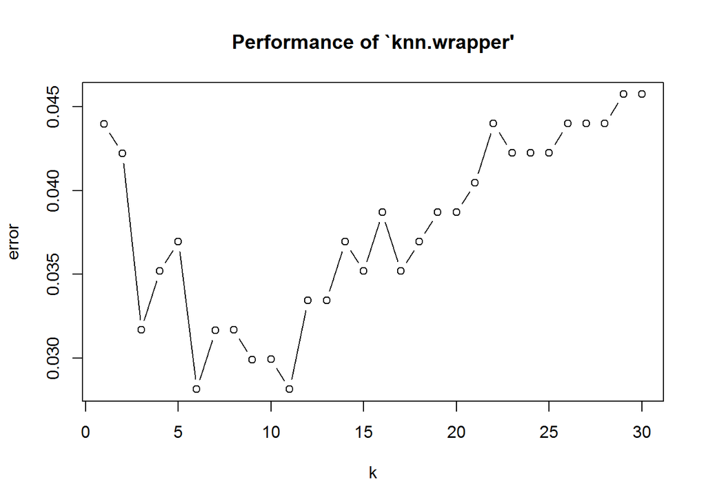

```r
plot(knn.cross)
```

## 4.2 Boostrap

On peut également faire du rééchantillonage :

```r
knn.boot <- tune.knn(x =  data_n[,1:30], y = data_n$class, k = 1:30,tunecontrol=tune.control(sampling = "boot") )
#Summarize the resampling results set
summary(knn.boot)
```

```
##
## Parameter tuning of 'knn.wrapper':
##
## - sampling method: bootstrapping
##
## - best parameters:
##   k
##  11
##
## - best performance: 0.03257829
##
## - Detailed performance results:
##     k      error dispersion
## 1   1 0.04525326 0.01127355
## 2   2 0.04070546 0.01730667
## 3   3 0.04036975 0.02055701
## 4   4 0.04027261 0.02021173
## 5   5 0.03346338 0.01307265
## 6   6 0.03552258 0.01603356
## 7   7 0.03599054 0.01671547
## 8   8 0.03516513 0.01853870
## 9   9 0.03640136 0.02047513
## 10 10 0.03515419 0.01902096
## 11 11 0.03257829 0.01898602
## 12 12 0.03386142 0.02004618
## 13 13 0.03465857 0.02264522
## 14 14 0.03555417 0.01971319
## 15 15 0.03555636 0.01964012
## 16 16 0.03633437 0.01900077
## 17 17 0.03554405 0.01893566
## 18 18 0.03643222 0.01767187
## 19 19 0.03642652 0.01760911
## 20 20 0.03605397 0.01833444
## 21 21 0.03650530 0.01868555
## 22 22 0.03738252 0.01995632
## 23 23 0.03785140 0.01977977
## 24 24 0.03784895 0.01934309
## 25 25 0.03821932 0.01872090
## 26 26 0.03732656 0.01936911
## 27 27 0.03909896 0.01932394
## 28 28 0.03955711 0.02118130
## 29 29 0.04255404 0.02002235
## 30 30 0.04118776 0.02008619
```

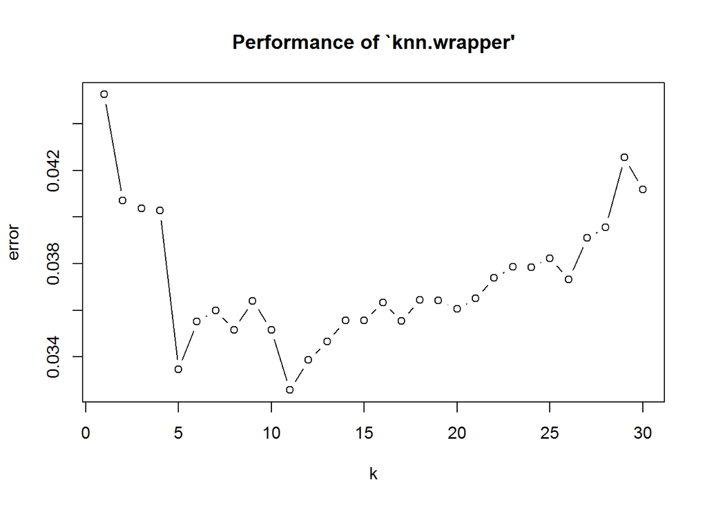

```r
plot(knn.boot)
```

# 5 Algorithme finale

On ne constate pas une unique valeur de k pour laquelle le taux d’erreurs est le plus bas. Les valeurs entre 5 et 15 semblent toutes pertinentes.